# Yelp Model

## Predicting a Yelp User's Average Rating of Italian Restaurants

This model uses a two-step process to predict a Yelp user's average rating of Italian restaurants.

The first step is to cluster Yelp restaurants based on their categories. Since we are predicting Italian restaurant ratings, Italian restaurants are removed from the clustering step. This clustering is performed with DBSCAN using an L1 metric and an epsilon of 1 (i.e. two restaurants that differ by one category are considered in the same "neighborhood").

Then, a training set is created of users that have reviewed at least 5 Italian restaurants. A portion of this training set is held out to test the accuracy of the model. Each user's average rating by cluster is calculated. These ratings are then used as inputs to train a neural network model with the user's average rating of Italian restaurants as the output.

```python
import json
import pandas as pd
import tensorflow as tf
import warnings
warnings.simplefilter("ignore")

from matplotlib import pyplot as plt
from pprint import pprint
from sklearn.cluster import DBSCAN
from sklearn.metrics import r2_score, mean_absolute_error
from sklearn.model_selection import train_test_split
```

Loading in restaurant data

```python
restaurants = []
with open('I:/yelp_dataset/restaurant_data/restaurant.json', encoding='utf-8') as f:
    for line in f:
        restaurant = json.loads(line)
        restaurant['categories'] = [x.strip() for x in restaurant['categories'].split(',')]
        restaurants.append(restaurant)
```

```python
italian_restaurants = [x for x in restaurants if 'Italian' in x['categories']]
other_restaurants = [x for x in restaurants if 'Italian' not in x['categories']]
```

Getting restaurant categories

```python
categories = set()
for restaurant in restaurants:
    for category in restaurant['categories']:
        categories.add(category)
print(len(categories))
```

```
811
```

Saving restaurant categories

```python
with open('I:/yelp_dataset/restaurant_data/categories.json', mode='w') as f:
    json.dump(list(categories), f)
```

```python
def restaurant_to_row(restaurant, categories):
    row = {i: 0 for i in categories}
    row['business_id'] = restaurant['business_id']
    for category in restaurant['categories']:
        row[category] = 1
    return row
```

```python
other_restaurant_rows = [restaurant_to_row(x, categories) for x in other_restaurants]
```

```python
df = pd.DataFrame(other_restaurant_rows)
X = df.drop('business_id', axis=1)
```

```python
%%time
# CAUTION! This step may take several hours
model = DBSCAN(eps=1, metric='l1')
model.fit(df.drop('business_id', axis=1))
```

```
Wall time: 1h 22min 33s
```

```
DBSCAN(algorithm='auto', eps=1, leaf_size=30, metric='l1', metric_params=None,
       min_samples=5, n_jobs=None, p=None)
```

```python
len(model.components_)
```

```
49476
```

```python
pd.Series(model.labels_).value_counts()
```

```
 0     51201
-1      6712
 1       531
 8        96
 7        44
 2        35
 11       34
 12       32
 17       23
 3        19
 9        18
 6        16
 10       14
 20       12
 25       12
```

[output cut: 22 more lines]

```python
labeled_df = df.drop('Restaurants', axis=1)
labeled_df['label'] = model.labels_ + 1
labeled_df
```

|  | Supper Clubs | Blow Dry/Out Services | Commercial Real Estate | Greek | Laundry Services | Coffee Roasteries | Wills | Tabletop Games | Home Decor | Climbing | ... | Personal Shopping | Windows Installation | Men's Clothing | Hostels | Hair Stylists | Office Equipment | Handyman | Window Washing | business_id | label |
| --- | --- | --- | --- | --- | --- | --- | --- | --- | --- | --- | --- | --- | --- | --- | --- | --- | --- | --- | --- | --- | --- |
| 0 | 0 | 0 | 0 | 0 | 0 | 0 | 0 | 0 | 0 | 0 | ... | 0 | 0 | 0 | 0 | 0 | 0 | 0 | 0 | pQeaRpvuhoEqudo3uymHIQ | 0 |
| 1 | 0 | 0 | 0 | 0 | 0 | 0 | 0 | 0 | 0 | 0 | ... | 0 | 0 | 0 | 0 | 0 | 0 | 0 | 0 | CsLQLiRoafpJPJSkNX2h5Q | 1 |
| 2 | 0 | 0 | 0 | 0 | 0 | 0 | 0 | 0 | 0 | 0 | ... | 0 | 0 | 0 | 0 | 0 | 0 | 0 | 0 | eBEfgOPG7pvFhb2wcG9I7w | 1 |
| 3 | 0 | 0 | 0 | 0 | 0 | 0 | 0 | 0 | 0 | 0 | ... | 0 | 0 | 0 | 0 | 0 | 0 | 0 | 0 | lu7vtrp_bE9PnxWfA8g4Pg | 1 |
| 4 | 0 | 0 | 0 | 0 | 0 | 0 | 0 | 0 | 0 | 0 | ... | 0 | 0 | 0 | 0 | 0 | 0 | 0 | 0 | 9sRGfSVEfLhN_km60YruTA | 1 |
| ... | ... | ... | ... | ... | ... | ... | ... | ... | ... | ... | ... | ... | ... | ... | ... | ... | ... | ... | ... | ... | ... |
| 58944 | 0 | 0 | 0 | 0 | 0 | 0 | 0 | 0 | 0 | 0 | ... | 0 | 0 | 0 | 0 | 0 | 0 | 0 | 0 | xVpE01l6ZXdEtVf5PkRpDg | 1 |
| 58945 | 0 | 0 | 0 | 0 | 0 | 0 | 0 | 0 | 0 | 0 | ... | 0 | 0 | 0 | 0 | 0 | 0 | 0 | 0 | BAVuLTDmpSzDCk37A5HjtQ | 1 |
| 58946 | 0 | 0 | 0 | 0 | 0 | 0 | 0 | 0 | 0 | 0 | ... | 0 | 0 | 0 | 0 | 0 | 0 | 0 | 0 | hskVqZCPqy-omm9CHi44xQ | 1 |
| 58947 | 0 | 0 | 0 | 0 | 0 | 0 | 0 | 0 | 0 | 0 | ... | 0 | 0 | 0 | 0 | 0 | 0 | 0 | 0 | 9Q0fPWAjUweoFDk0kafuzQ | 1 |
| 58948 | 0 | 0 | 0 | 0 | 0 | 0 | 0 | 0 | 0 | 0 | ... | 0 | 0 | 0 | 0 | 0 | 0 | 0 | 0 | SYa2j1boLF8DcGVOYfHPcA | 1 |

58949 rows × 812 columns

```python
labeled_df[['business_id', 'label']].to_json('I:/yelp_dataset/restaurant_data/business_clusters.json', orient='records')
```

```python
vectors = labeled_df.groupby('label').mean()
counts = labeled_df.groupby('label')['label'].count()

for cluster in range(labeled_df['label'].max()):
    print(f'\nCluster {cluster}, count: {counts[cluster]}')
    temp_df = vectors.transpose()[cluster].sort_values(ascending=False)
    identifying_categories = temp_df[temp_df > 0.9]
    [print(x) for x in identifying_categories.index] if len(identifying_categories > 0) else print('()')
    print('\n')
    print(vectors.transpose()[cluster].sort_values(ascending=False).head())
    print('\n' + '-'*40)
```

```
Cluster 0, count: 6712
()


Food                         0.570918
Nightlife                    0.362485
Bars                         0.333731
Event Planning & Services    0.188468
American (Traditional)       0.171633
Name: 0, dtype: float64

----------------------------------------

Cluster 1, count: 51201
()


Food                      0.215074
Fast Food                 0.147595
Sandwiches                0.122419
American (Traditional)    0.115213
Nightlife                 0.111013
Name: 1, dtype: float64

----------------------------------------

Cluster 2, count: 531
Wine & Spirits
Food
Beer


Wine & Spirits    1.000000
Food              1.000000
Beer              1.000000
Nightlife         0.647834
Bars              0.638418
Name: 2, dtype: float64

----------------------------------------
```

[output cut: 545 more lines]

```
Cluster 34, count: 6
Bars
Jazz & Blues
Arts & Entertainment
Nightlife


Bars                    1.000000
Jazz & Blues            1.000000
Arts & Entertainment    1.000000
Nightlife               1.000000
Lounges                 0.833333
Name: 34, dtype: float64

----------------------------------------
```

```python
reviews = []
with open('I:/yelp_dataset/restaurant_data/review.json', encoding='utf-8') as f:
    for line in f:
        reviews = json.loads(line)
```

```python
df2 = pd.DataFrame(reviews[:-1]).merge(labeled_df[['business_id','label']], on='business_id', how='left')
df2['label'] = df2['label'].fillna(-1)
```

```python
italian_restaurant_reviewers = df2[df2['label'] == -1].groupby('user_id').count()['label']
top_italian_restaurant_reviewers = italian_restaurant_reviewers[italian_restaurant_reviewers >= 5]
top_italian_restaurant_reviewers
```

```
user_id
---1lKK3aKOuomHnwAkAow    14
--2HUmLkcNHZp0xw6AMBPg    11
--Qh8yKWAvIP4V4K8ZPfHA    26
--cd_gA-9Q8gM9P2cTxEsQ     6
-0aInSHjCWLfiNqfgmWnow     5
                          ..
zyg4-MFtfPWmwucVazSjfw     6
zyjsU8rV-q-Wq7wFksVyJw    12
zynfOy36AZ0WsoGUYAjQaA     6
zzPvEodjvLPe-5NvV0U_cg    15
zzgb9L3NBT9V8BGw_DcVYw     6
Name: label, Length: 12614, dtype: int64
```

```python
italian_restaurant_ids = set([x['business_id'] for x in italian_restaurants])
italian_restaurant_reviewer_ids = [x['user_id'] for x in reviews[:-1] if x['business_id'] in italian_restaurant_ids]
```

```python
df3 = df2[df2['user_id'].isin(top_italian_restaurant_reviewers.index)].groupby(['user_id', 'label']).mean().reset_index().set_index('user_id').pivot(columns='label', values='stars')
df3
```

| label user_id | -1.0 | 0.0 | 1.0 | 2.0 | 3.0 | 4.0 | 5.0 | 6.0 | 7.0 | 8.0 | ... | 26.0 | 27.0 | 28.0 | 29.0 | 30.0 | 31.0 | 32.0 | 33.0 | 34.0 | 35.0 |
| --- | --- | --- | --- | --- | --- | --- | --- | --- | --- | --- | --- | --- | --- | --- | --- | --- | --- | --- | --- | --- | --- |
| ---1lKK3aKOuomHnwAkAow | 3.142857 | 4.142857 | 3.731707 | NaN | NaN | NaN | NaN | NaN | NaN | NaN | ... | NaN | NaN | NaN | NaN | NaN | NaN | NaN | NaN | NaN | NaN |
| --2HUmLkcNHZp0xw6AMBPg | 4.545455 | 4.950000 | 4.600000 | NaN | NaN | NaN | NaN | NaN | NaN | NaN | ... | NaN | NaN | NaN | NaN | NaN | NaN | NaN | NaN | NaN | NaN |
| --Qh8yKWAvIP4V4K8ZPfHA | 3.115385 | 3.472222 | 2.982353 | 3.2 | NaN | 3.0 | NaN | NaN | NaN | NaN | ... | 3.0 | NaN | NaN | NaN | NaN | NaN | NaN | NaN | NaN | NaN |
| --cd_gA-9Q8gM9P2cTxEsQ | 4.166667 | 4.142857 | 4.172414 | NaN | NaN | NaN | NaN | NaN | NaN | NaN | ... | NaN | NaN | NaN | NaN | NaN | NaN | NaN | NaN | NaN | NaN |
| -0aInSHjCWLfiNqfgmWnow | 4.600000 | 4.200000 | 3.975610 | 4.0 | NaN | NaN | NaN | NaN | NaN | NaN | ... | NaN | NaN | NaN | NaN | NaN | NaN | NaN | 5.0 | NaN | NaN |
| ... | ... | ... | ... | ... | ... | ... | ... | ... | ... | ... | ... | ... | ... | ... | ... | ... | ... | ... | ... | ... | ... |
| zyg4-MFtfPWmwucVazSjfw | 3.166667 | 2.875000 | 3.528846 | NaN | NaN | NaN | NaN | NaN | NaN | NaN | ... | NaN | NaN | NaN | NaN | NaN | NaN | NaN | NaN | NaN | NaN |
| zyjsU8rV-q-Wq7wFksVyJw | 4.416667 | 4.000000 | 4.071429 | NaN | NaN | NaN | NaN | NaN | NaN | NaN | ... | NaN | NaN | NaN | NaN | NaN | NaN | NaN | NaN | NaN | NaN |
| zynfOy36AZ0WsoGUYAjQaA | 3.500000 | 3.500000 | 3.680000 | NaN | NaN | NaN | NaN | NaN | NaN | NaN | ... | NaN | NaN | NaN | NaN | NaN | NaN | NaN | NaN | NaN | NaN |
| zzPvEodjvLPe-5NvV0U_cg | 3.000000 | 3.000000 | 2.930556 | NaN | NaN | NaN | NaN | NaN | NaN | NaN | ... | NaN | NaN | NaN | NaN | NaN | NaN | NaN | NaN | NaN | 4.0 |
| zzgb9L3NBT9V8BGw_DcVYw | 4.500000 | 4.250000 | 4.153846 | 4.0 | NaN | NaN | NaN | NaN | NaN | NaN | ... | NaN | NaN | NaN | NaN | NaN | NaN | NaN | NaN | NaN | NaN |

12614 rows × 37 columns

```python
X = df3.drop(-1, axis=1).fillna(3)
y = df3[-1]
X_train, X_test, y_train, y_test = train_test_split(X, y, random_state=42)
nn_model = tf.keras.Sequential()
nn_model.add(tf.keras.layers.Dense(units=1, input_dim=len(X.columns)))
nn_model.compile(loss="MSE", optimizer="adam", metrics=["mse", "mae"])
fit_model = nn_model.fit(X_train, y_train, epochs=50)
```

```python
nn_model.save("yelp_model.h5")
```

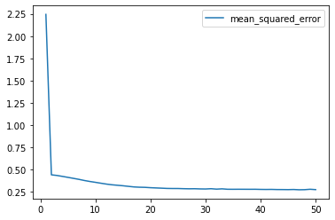

```python
pd.DataFrame(fit_model.history, index=range(1,len(fit_model.history["loss"])+1)).plot(y="mean_squared_error")
```

```python
r2_score(y_test, nn_model.predict(X_test))
```

```
0.353993709084813
```

```python
mean_absolute_error(y_test, nn_model.predict(X_test))
```

```
0.39970593421709116
```

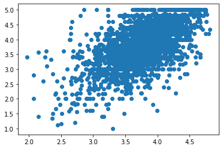

```python
plt.scatter(nn_model.predict(X_test), y_test)
```

##### Conclusion:

While the R-square of 0.35 shows there is room for improvement in the model, on average, the model is within .4 stars of the actual result